Connected to ccaes_dashboard (Python 3.10.13)

# Understanding Participation Patterns: Classifying MA-User Behavior

```python
import os
import sys
from pathlib import Path

import numpy as np
import pandas as pd
from scipy.stats import hmean
from sklearn.cluster import AgglomerativeClustering, SpectralClustering
from sklearn.preprocessing import MinMaxScaler, Normalizer

root_dir = Path(os.getcwd()).parent
config_path = root_dir.joinpath("config/")
sys.path.append(str(root_dir))

from src import ppa, query_engine
from src.utils import get_config, get_config_filenames

%load_ext autoreload
%autoreload 2

# Get configuration parameters and logger for the current session
config = get_config(path=config_path)
config = get_config(["config.ini"], path=config_path)
config = get_config(get_config_filenames(config["params"]["env"], config_path))

RANDOM_STATE = 0
START_DATE = "2020-01-01"
COLORS = [
    "#669900ff",
    "#003399ff",
    "#2971ffff",
    "#ff6600ff",
    "#ffcc00ff",
    "#bfbfbfff",
]
```

Load the precomputed point-pattern analysis dataset.

```python
qe = query_engine.QueryEngine(config)
qe_ppa = ppa.QueryEngine(config)
qe_ppa.run_ppa(refresh_users_ppa=False)
viz = ppa.Viz(config)

users_stats = pd.read_parquet(config["paths"]["users_ppa_quality"]).set_index("user_id")
```

```
2024-06-28 20:45:08.670 | INFO     | src.log:wrapper:120 - Task Started - run_ppa
2024-06-28 20:45:09.755 | INFO     | src.ppa:get_users_quality:440 - Completed: users_quality
2024-06-28 20:45:10.063 | INFO     | src.log:wrapper:126 - Task Completed - run_ppa - Execution time: 1.39 seconds
```

## Heuristic profiling of users

We establish threshold values for categorizing users based on their spatial dispersion and their participation quality. Users with a high 'adults_ratio' value primarily contribute adult-mosquito reports, which typically demand more time and effort, while those with a low value engage more frequently with reports on bites and breeding sites. The assumption is that users inclined to submit adult-mosquito reports are more valuable since they invest greater effort per MA-app interaction. Apart from how many adult-reports are submitted by a user, it is relevant if those are target-species, measured by the 'quality_target'. At this point, it is possible to aggregate quality related measures with a harmonic mean since it's useful when dealing with rates or ratios, as it tends to give more weight to lower values. There are many cases of 'sporadic' users that send only one report where 'quality_target' is 0 but 'adults_ratio' is 1; in this case the arithmetic mean would yields 0.5 while a h-mean pulls the result toward 0 acting as a logic AND.

There are three levels of user rule-based partitioning, with an increasing hierarchical complexity. Level-1 only partition by the number of cluster, Level-2 adds the partition by user quality, while Level-3 considers all three decision variables including spatial dispersion (std_utm).

Here we emphasize the difficulty of using 'quality_reports' for user profiling. The discussion revolves around users' accountability in EntoLab's post-processing procedures. Despite users submitting high-quality photos, their report-quality score often fails to reflect their efforts due to species correlation with identification task difficulty. For instance, even if a user consistently submits excellent photos of Ae. Japonicus, experts are likely to assign a lower confidence level or to disagree more often because of the inherently difficult identification task. Assessing user-submitted photo quality remains challenging, with estimations focusing at most on photographic quality rather than experts-agreement and confidence. As consequence, here we exclude 'quality_report' variable from user profiling analysis.

```python
std_lim = 1000
quality_lim = 2.0 / 3
quality_model = "with_additive_cs_acc"

labels, users_global_competence, users_acc = ppa.users_competence(config)

users_stats["adults_ratio"] = users_stats["n_reports"] / users_stats["n_points"]
users_stats["accuracy"] = users_acc["accuracy"]
users_stats["accuracy_chance_adj"] = users_acc["accuracy_chance_adj"]
users_stats["accuracy_chance_adj_pos"] = (
    users_stats["accuracy_chance_adj"].fillna(0).clip(lower=0)
)

match quality_model:
    case "without_cs_acc":
        users_stats["quality"] = hmean(
            users_stats[["adults_ratio", "quality_target"]], axis=1
        )
    case "with_additive_cs_acc":
        users_stats["quality"] = (
            hmean(users_stats[["adults_ratio", "quality_target"]], axis=1)
            + users_stats["accuracy_chance_adj_pos"]
        ) / 2

# Rollover all level of heuristic labels
levels = {1: [None, None], 2: [None, quality_lim], 3: [std_lim, quality_lim]}
for level in [1, 2, 3]:
    std_lim_, quality_lim_ = levels[level]
    users_stats[f"custom_labels_{level}"] = users_stats.apply(
        ppa.user_labels, std_lim=std_lim_, quality_lim=quality_lim_, axis=1
    )
```

```
Overall CS chance adjusted accuracy: 0.84
Percentage of low accuracy cs-labels: 40.7
Overall CS classification report:
             aegypti    albopictus        culex   japonicus    koreicus  \
precision   0.034820      0.967454     0.963151    0.630303    0.155378
recall      0.695652      0.897793     0.978507    0.369449    0.251613
f1-score    0.066321      0.931323     0.970768    0.465845    0.192118
support    46.000000  12416.000000  9910.000000  563.000000  155.000000

           accuracy     macro avg  weighted avg
precision  0.914812      0.550221      0.950077
recall     0.914812      0.638603      0.914812
f1-score   0.914812      0.525275      0.930217
support    0.914812  23090.000000  23090.000000
```

If we examine the distribution of user accuracy, adjusted for chance, between frequent participants (more than 5 reports) and sporadic contributors (fewer than 5 reports), we observe that the former group exhibits a more evenly distributed range of values. In contrast, sporadic users' accuracy values are predominantly 0 or 1 due to the limited data available for accurate evaluation. Additionally, it is worth noting that motivated users perform slightly better than sporadic ones.

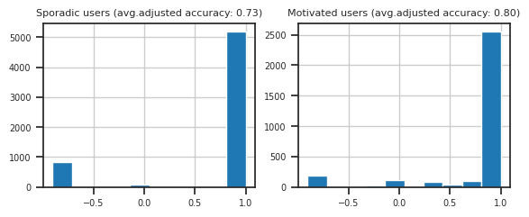

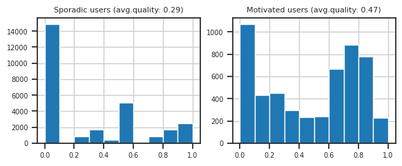

```python
viz.users_quality(users_stats, metric="adjusted accuracy")

# When examining the distribution of User Quality (UQ), motivated users provide,
# on average, higher quality reports compared to sporadic users. Notably, the
# overall number of users considered for UQ is higher than for accuracy evaluation,
# as some users did not supply annotations for adult mosquito reports and thus
# accuracy were not evaluated. However, in computing UQ, when accuracy is missing
# UA takes a value of zero.

viz.users_quality(users_stats, metric="quality")
```

### Overall user-profiling

Notably, the majority of users are retained for up to 1 year. User labeling considers entire participation history, cautioning against aggregating user distributions below monthly intervals. For robust analysis, quarterly and yearly intervals are recommended at expense of local insights. Note that only validated reports are considered since the quality score is computed in relation to expert validation.

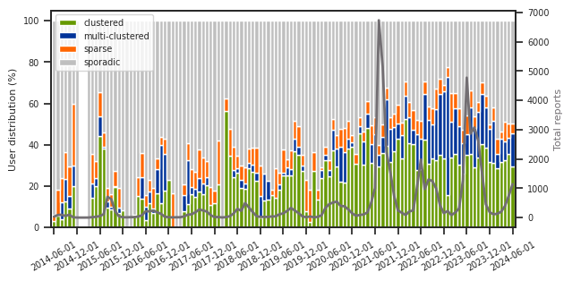

```python
entity = "Total"
level = 1

users_stats_view = qe.ppa_view_inflow(
    users_stats, f"custom_labels_{level}", entity=entity, freq="month"
)
# Overall diagram
viz.level_users_stats(
    users_stats_view,
    level,
    ticker_moltip=6,
    stacked=True,
    is_palette=False,
)
```

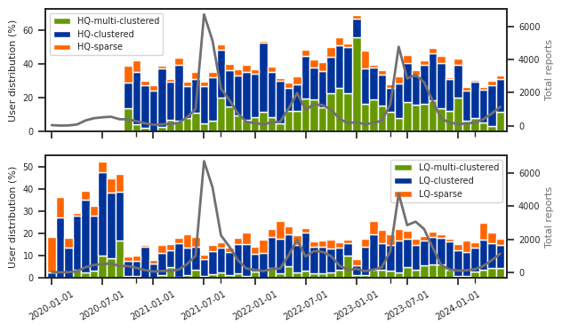

```python
level = 2
users_stats_view = qe.ppa_view_inflow(
    users_stats, f"custom_labels_{level}", entity=entity, freq="month"
)
viz.level_users_stats(
    users_stats_view.loc[START_DATE:],
    level,
    ticker_moltip=6,
    stacked=True,
    is_palette=False,
    save_data=True,
    title=entity,
)
```

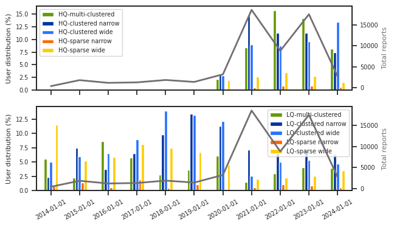

```python
level = 3
users_stats_view = qe.ppa_view_inflow(
    users_stats, f"custom_labels_{level}", entity=entity, freq="year"
)
viz.level_users_stats(
    users_stats_view, level, ticker_moltip=None, stacked=False, is_palette=False
)
```

### Spain user-profiling

The second hierarchical level, aggregated monthly, separates users into high-quality (upper figure) and low-quality (lower) categories for clearer visualization.

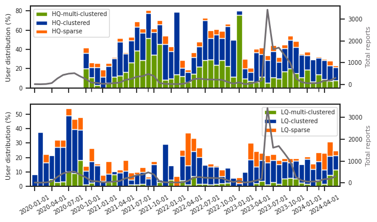

```python
entity = "Spain"
level = 2
users_stats_view = qe.ppa_view_inflow(
    users_stats, f"custom_labels_{level}", entity=entity, freq="month"
)
# Global picture
viz.level_users_stats(
    users_stats_view.loc[START_DATE:, :],
    level,
    ticker_moltip=3,
    stacked=True,
    is_palette=False,
    save_data=True,
    title=entity,
)
```

### Italy user-profiling

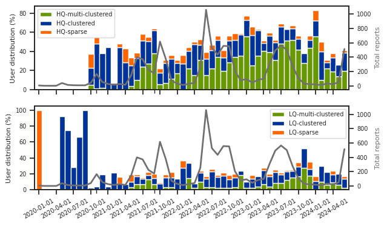

```python
entity = "Italy"
level = 2
users_stats_view = qe.ppa_view_inflow(
    users_stats, f"custom_labels_{level}", entity=entity, freq="month"
)
# Global picture
viz.level_users_stats(
    users_stats_view.loc[START_DATE:, :],
    level,
    ticker_moltip=3,
    stacked=True,
    is_palette=False,
    save_data=True,
    title=entity,
)
```

### Netherlands user-profiling

The surge in clustered users following the Netherlands' surge event is evidently driven primarily by low-quality users. Subsequent to the main communication event, the persisting user base comprises predominantly clustered users, with sporadic users gradually diminishing as no further communication events engage them.

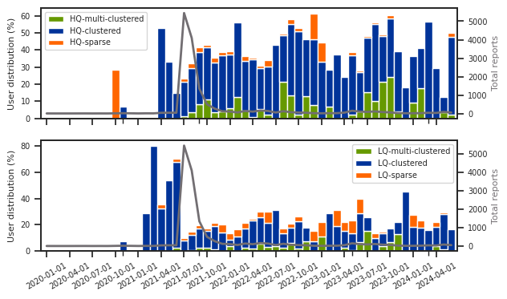

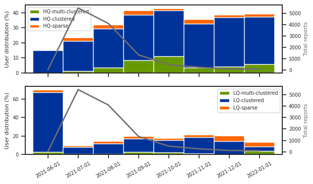

```python
entity = "Netherlands"
level = 2
users_stats_view = qe.ppa_view_inflow(
    users_stats, f"custom_labels_{level}", entity=entity, freq="month"
)
# Global picture
viz.level_users_stats(
    users_stats_view.loc[START_DATE:, :],
    level,
    ticker_moltip=3,
    stacked=True,
    is_palette=False,
    save_data=True,
    title=entity,
)
# Highlight of the surge event
viz.level_users_stats(
    users_stats_view.loc["2021-06-01":"2022-01-01"],
    level,
    ticker_moltip=None,
    stacked=True,
    is_palette=False,
)
```

## Exploratory Data Analysis

### User Retention

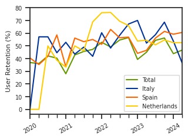

```python
entities = ["Total", "Italy", "Spain", "Netherlands"]
colors = [
    "#669900ff",
    "#003399ff",
    "#ff6600ff",
    "#ffcc00ff",
]
viz.user_retention(qe, entities, freq="quarter", start_date=START_DATE, colors=colors)
```

### MA Active Users

Here, we briefly explore user retention across different 'recency' periods. For example, with a recency interval of one year, we count all users who have uploaded their most recent report within the past year and mark them as active. New users are defined as those who have uploaded at least one report. A user's first report serves as the time-marker for their registration in the MA system. Note that merely installing the MA app does not qualify someone as a "new user"; uploading at least one report is required. The percentage of active users is calculated as the fraction of active users among new users, aggregated on a monthly basis. The following diagram shows the number of active users participating in MA as the definition of recency changes.

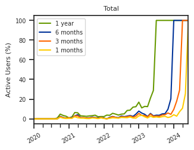

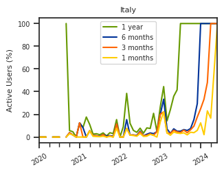

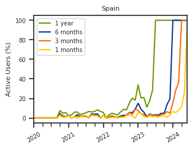

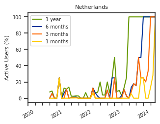

```python
retention_interval = ["1 year", "6 months", "3 months", "1 months"]
for entity in entities:
    viz.active_users(qe, retention_interval, entity=entity, start_date=START_DATE, colors=colors)
```